# 9.7: Exercises

# Applied

## Question 4

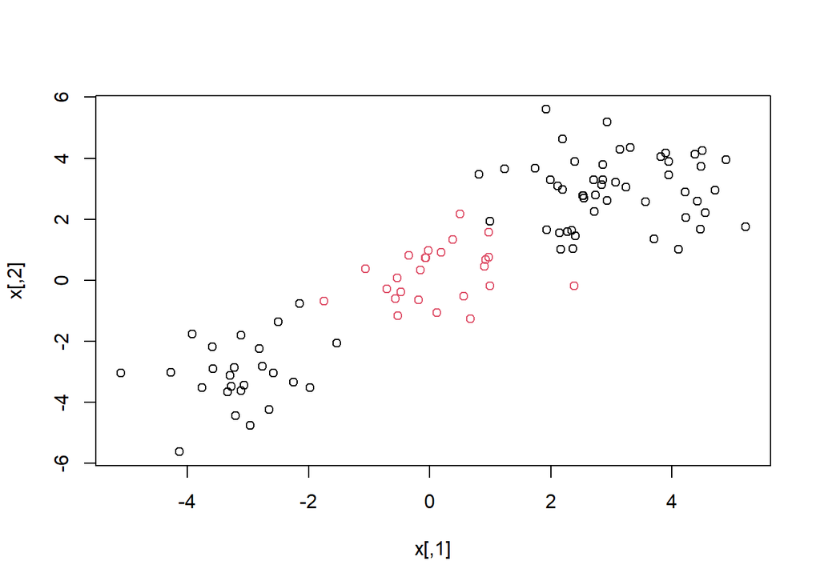

```r
set.seed(5)
x = matrix(rnorm(100*2), ncol=2)
x[1:50,] = x[1:50,] + 3
x[51:75,] = x[51:75,] - 3
y = c(rep(1,75), rep(2,25))
plot(x, col=y)
```

```r
set.seed(5)
df4 = data.frame(x=x, y=as.factor(y))
train = sample(100,60)
```

```r
library(e1071)
set.seed(5)
lin.tune = tune( svm, y~., data = df4[train,], kernel="linear", scale=F,
                 ranges=list(cost=c(0.001,0.001,0.1,1,5,10,100)))
summary(lin.tune)
```

```
##
## Parameter tuning of 'svm':
##
## - sampling method: 10-fold cross validation
##
## - best parameters:
##   cost
##  0.001
##
## - best performance: 0.2166667
##
## - Detailed performance results:
##    cost     error dispersion
## 1 1e-03 0.2166667  0.2086109
## 2 1e-03 0.2166667  0.2086109
## 3 1e-01 0.2166667  0.2086109
## 4 1e+00 0.2166667  0.2086109
## 5 5e+00 0.2166667  0.2086109
## 6 1e+01 0.2166667  0.2086109
## 7 1e+02 0.2166667  0.2086109
```

Our best linear model has a cost=0.001 with a training error rate of 0.217. Now, we look at a polynomial kernel for svm.

```r
set.seed(5)
pol.tune = tune( svm, y~., data = df4[train,], kernel="polynomial", scale=F,
                 ranges=list(cost=c(0.01,0.1,1),degree=c(2,3,4)))
summary(pol.tune)
```

```
##
## Parameter tuning of 'svm':
##
## - sampling method: 10-fold cross validation
##
## - best parameters:
##  cost degree
##   0.1      2
##
## - best performance: 0
##
## - Detailed performance results:
##   cost degree      error dispersion
## 1 0.01      2 0.08333333 0.08784105
## 2 0.10      2 0.00000000 0.00000000
## 3 1.00      2 0.01666667 0.05270463
## 4 0.01      3 0.21666667 0.20861093
## 5 0.10      3 0.21666667 0.20861093
## 6 1.00      3 0.21666667 0.20861093
## 7 0.01      4 0.03333333 0.07027284
## 8 0.10      4 0.03333333 0.07027284
## 9 1.00      4 0.03333333 0.07027284
```

```r
set.seed(5)
rad.tune = tune( svm, y~., data = df4[train,], kernel="radial", scale=F,
                 ranges=list(cost=c(0.01,0.1,1),gamma=c(0.1,1,2,5)))
summary(rad.tune)
```

```
##
## Parameter tuning of 'svm':
##
## - sampling method: 10-fold cross validation
##
## - best parameters:
##  cost gamma
##     1   0.1
##
## - best performance: 0.01666667
##
## - Detailed performance results:
##    cost gamma      error dispersion
## 1  0.01   0.1 0.21666667 0.20861093
## 2  0.10   0.1 0.21666667 0.20861093
## 3  1.00   0.1 0.01666667 0.05270463
## 4  0.01   1.0 0.21666667 0.20861093
## 5  0.10   1.0 0.21666667 0.20861093
## 6  1.00   1.0 0.03333333 0.07027284
## 7  0.01   2.0 0.21666667 0.20861093
## 8  0.10   2.0 0.21666667 0.20861093
## 9  1.00   2.0 0.06666667 0.11653432
## 10 0.01   5.0 0.21666667 0.20861093
## 11 0.10   5.0 0.21666667 0.20861093
## 12 1.00   5.0 0.10000000 0.11653432
```

Our best radial model has a cost=1 and gamma=0.1 with a training error rate of 0.017. Now, we look at the test accuracies

```r
table(true=df4[-train, "y"], pred=predict(lin.tune$best.model, newdata = df4[-train,]))
```

```
##     pred
## true  1  2
##    1 28  0
##    2 12  0
```

```r
28/40
```

```
## [1] 0.7
```

```r
table(true=df4[-train, "y"], pred=predict(pol.tune$best.model, newdata = df4[-train,]))
```

```
##     pred
## true  1  2
##    1 28  0
##    2  1 11
```

```r
(28+11)/40
```

```
## [1] 0.975
```

```r
table(true=df4[-train, "y"], pred=predict(rad.tune$best.model, newdata = df4[-train,]))
```

```
##     pred
## true  1  2
##    1 28  0
##    2  2 10
```

```r
(28+10)/40
```

```
## [1] 0.95
```

Hence, both the polynomial and radial kernel-based SVMs perform far better on our non-linear dataset both in terms of training accuracy and test accuracy.

## Question 5

### a

```r
x1 = runif(500) - 0.5
x2 = runif(500) - 0.5
y = 1 * (x1^2 - x2^2 > 0)
```

### b

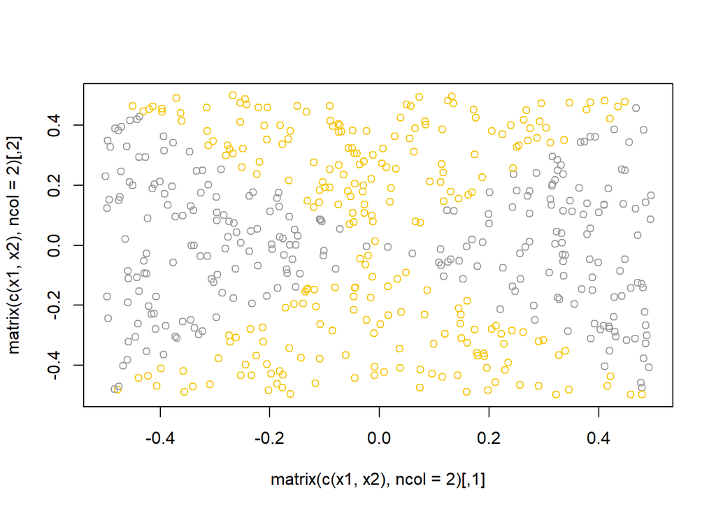

```r
plot(matrix(c(x1,x2), ncol=2), col=y+7)
```

### c

```r
df5 = data.frame( x= matrix(c(x1,x2), ncol=2), y=as.factor(y))
set.seed(5)
library(glmnet)
log.mod = glm( y~., data = df5, family="binomial")
summary(log.mod)
```

```
##
## Call:
## glm(formula = y ~ ., family = "binomial", data = df5)
##
## Deviance Residuals:
##    Min      1Q  Median      3Q     Max
## -1.270  -1.164   1.095   1.168   1.240
##
## Coefficients:
##             Estimate Std. Error z value Pr(>|z|)
## (Intercept)  0.02204    0.08975   0.246    0.806
## x.1          0.01620    0.30725   0.053    0.958
## x.2         -0.37328    0.31289  -1.193    0.233
##
## (Dispersion parameter for binomial family taken to be 1)
##
##     Null deviance: 693.12  on 499  degrees of freedom
## Residual deviance: 691.68  on 497  degrees of freedom
## AIC: 697.68
##
## Number of Fisher Scoring iterations: 3
```

### d

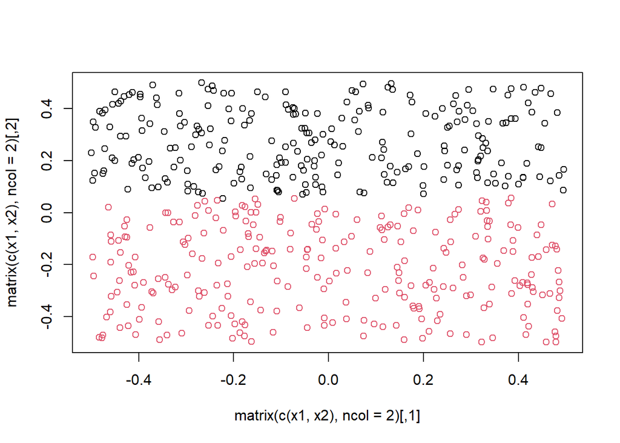

```r
log.pred = predict(log.mod, type = "response")
log.class = rep(0,500)
log.class[log.pred > 0.5] = 1

plot(matrix(c(x1,x2), ncol=2), col=log.class+1)
```

### e

```r
set.seed(5)
log.mod2 = glm( y ~ poly(x.1,2)+log(x.2)+I(x.1*x.2), data = df5, family="binomial")
summary(log.mod2)
```

```
##
## Call:
## glm(formula = y ~ poly(x.1, 2) + log(x.2) + I(x.1 * x.2), family = "binomial",
##     data = df5)
##
## Deviance Residuals:
##     Min       1Q   Median       3Q      Max
## -4.2722  -0.3099  -0.0496   0.2279   1.8362
##
## Coefficients:
##               Estimate Std. Error z value Pr(>|z|)
## (Intercept)    -6.9405     1.0466  -6.631 3.33e-11 ***
## poly(x.1, 2)1   5.7909    15.5843   0.372    0.710
## poly(x.1, 2)2  74.5442    10.3929   7.173 7.36e-13 ***
## log(x.2)       -4.5366     0.6782  -6.689 2.25e-11 ***
## I(x.1 * x.2)   -0.6928     6.8078  -0.102    0.919
## ---
## Signif. codes:  0 '***' 0.001 '**' 0.01 '*' 0.05 '.' 0.1 ' ' 1
##
## (Dispersion parameter for binomial family taken to be 1)
##
##     Null deviance: 364.14  on 262  degrees of freedom
## Residual deviance: 129.31  on 258  degrees of freedom
##   (237 observations deleted due to missingness)
## AIC: 139.31
##
## Number of Fisher Scoring iterations: 7
```

### f

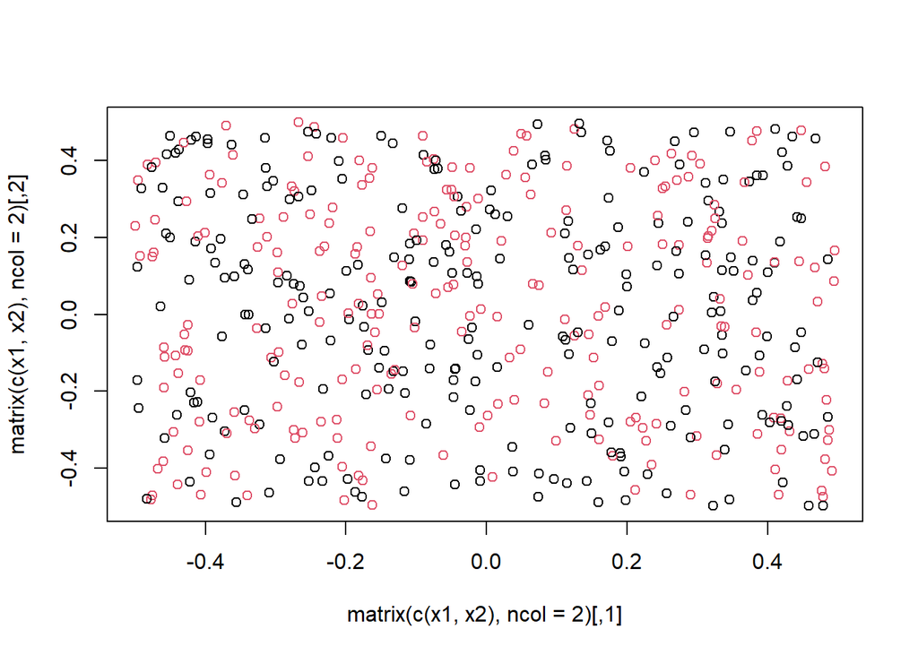

```r
log.pred2 = predict(log.mod2, type = "response")
log.class2 = rep(0,500)
log.class2[log.pred2 > 0.5] = 1

plot(matrix(c(x1,x2), ncol=2), col=log.class2+1)
```

### g

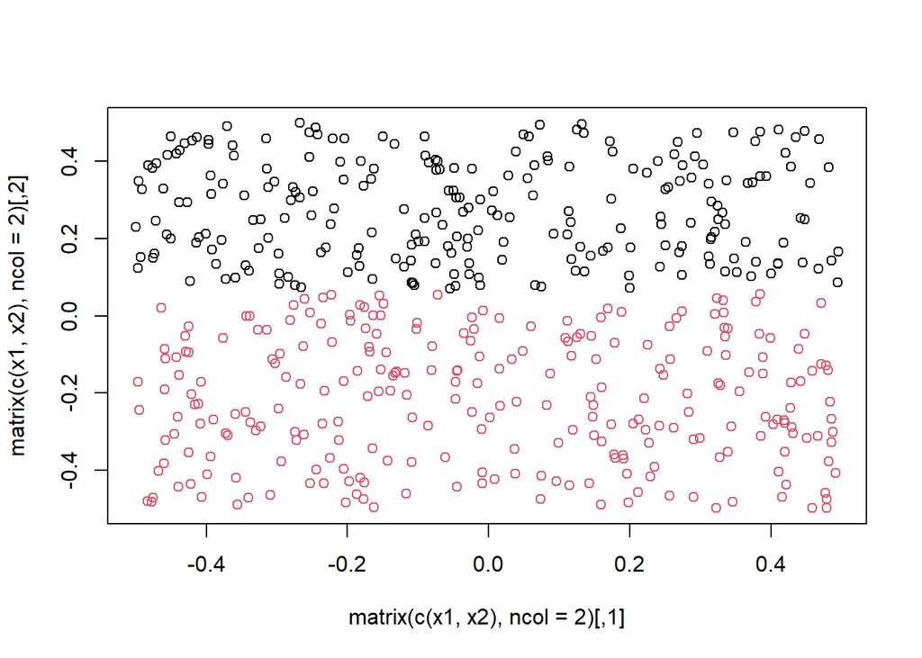

```r
set.seed(5)
svm.mod = svm( y~., data = df5, scale = F, cost=1, kernel="linear")

svm.pred = predict( svm.mod, newdata=df5 )
plot(matrix(c(x1,x2), ncol=2), col=type.convert(svm.pred, "vector")+1)
```

### h

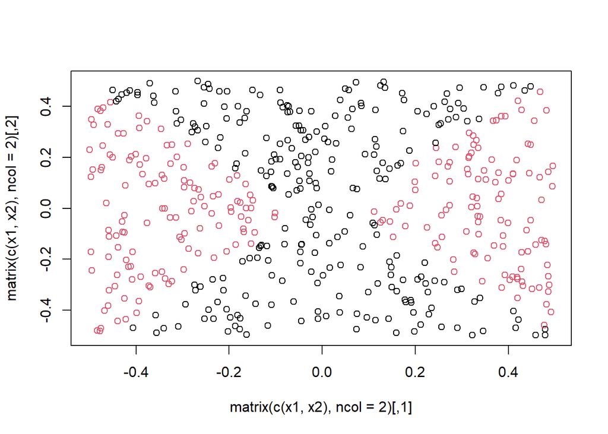

```r
set.seed(5)
svm.mod2 = svm( y~., data = df5, scale = F, cost=1, gamma=2, kernel="radial")

svm.pred2 = predict( svm.mod2, newdata=df5 )
plot(matrix(c(x1,x2), ncol=2), col=type.convert(svm.pred2, "vector")+1)
```

### i As expected, our non-linear kernel SVM perfomed better than our linear models due to the dataset being non-linear. Even though we know our data is quadratic, we chose a radial kernel above to show how it can result in a more generalised model that better suits our data.

## Question 6

### a

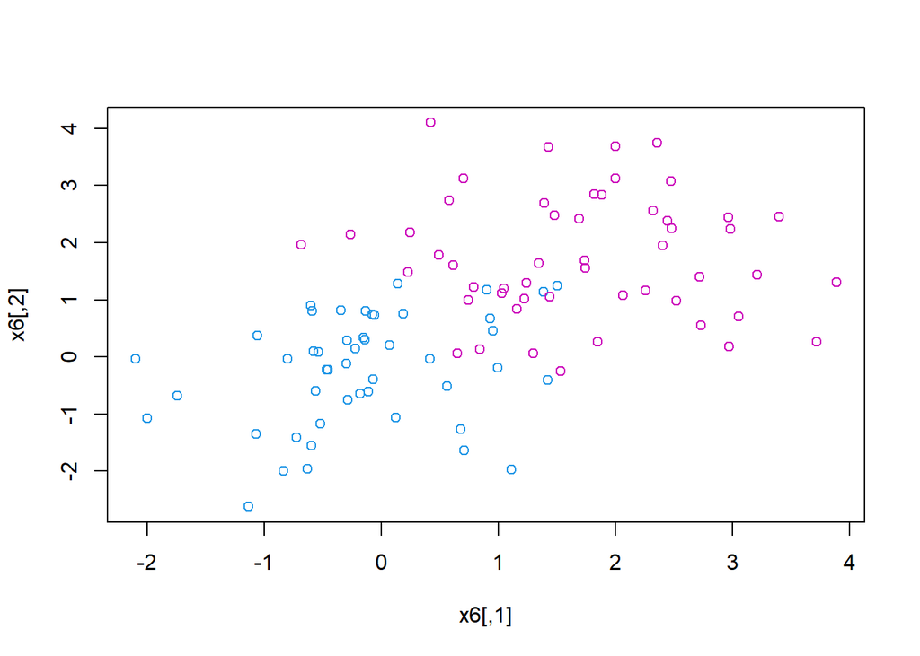

```r
set.seed(5)
x6 = matrix(rnorm(100*2), ncol=2)
y6 = sample(c(-1,1), 100, replace = TRUE)
x6[y6==1,] = x6[y6==1,] + 1.5

plot(x6, col=y6+5)
```

### b

```r
set.seed(5)
df6 = data.frame(x=x6, y=as.factor(y6))
tune.6 = tune(svm, y~., data=df6, kernel="linear", scale=F,
              ranges = list(cost=c(0.001, 0.01, 0.1, 1, 10, 100)))
summary(tune.6)
```

```
##
## Parameter tuning of 'svm':
##
## - sampling method: 10-fold cross validation
##
## - best parameters:
##  cost
##  0.01
##
## - best performance: 0.1
##
## - Detailed performance results:
##    cost error dispersion
## 1 1e-03  0.59 0.21317703
## 2 1e-02  0.10 0.08164966
## 3 1e-01  0.11 0.07378648
## 4 1e+00  0.11 0.07378648
## 5 1e+01  0.10 0.08164966
## 6 1e+02  0.10 0.08164966
```

Our best model is obtained with a cost funtion is 0.01, 10 or 100

### c

```r
set.seed(5)
xtest6 = matrix(rnorm(40*2), ncol=2)
ytest6 = sample(c(-1,1), 40, replace = TRUE)
xtest6[ytest6==1,] = xtest6[ytest6==1,] + 1
testdf6 = data.frame(x=xtest6, y=as.factor(ytest6))
```

```r
for (i in c(0.001, 0.01, 0.1, 1, 10, 100)){
  temp.mod = svm(y~., data=df6, scale=F, kernel="linear", cost=i)
  print(table(true=testdf6$y, pred=predict(temp.mod, newdata = testdf6)))
}
```

```
##     pred
## true -1  1
##   -1  0 24
##   1   0 16
##     pred
## true -1  1
##   -1 20  4
##   1   5 11
##     pred
## true -1  1
##   -1 20  4
##   1   4 12
##     pred
## true -1  1
##   -1 20  4
##   1   4 12
##     pred
## true -1  1
##   -1 20  4
##   1   4 12
##     pred
## true -1  1
##   -1 20  4
##   1   4 12
```

Our best model is obtained with any cost function greater than 0.01.

### d

As we can observe, increasing the cost parameter does not result in an increase in accuracy for our randomised dataset. But taking a lower value results in a more generalised model that might perform better for unseen data.

## Question 7

```r
library(ISLR)
df7 = Auto
head(df7)
```

|  | mpg | cylinders | displacement | horsepower | weight | acceleration | year | origin | name |
| --- | --- | --- | --- | --- | --- | --- | --- | --- | --- |
| 1 | 18 | 8 | 307 | 130 | 3504 | 12.0 | 70 | 1 | chevrolet chevelle malibu |
| 2 | 15 | 8 | 350 | 165 | 3693 | 11.5 | 70 | 1 | buick skylark 320 |
| 3 | 18 | 8 | 318 | 150 | 3436 | 11.0 | 70 | 1 | plymouth satellite |
| 4 | 16 | 8 | 304 | 150 | 3433 | 12.0 | 70 | 1 | amc rebel sst |
| 5 | 17 | 8 | 302 | 140 | 3449 | 10.5 | 70 | 1 | ford torino |
| 6 | 15 | 8 | 429 | 198 | 4341 | 10.0 | 70 | 1 | ford galaxie 500 |

### a

```r
df7$gasmil = rep(0,392)
med = median(df7$mpg)
df7$gasmil[ df7$mpg > med ] = 1
df7$gasmil = as.factor(df7$gasmil)
head(df7)
```

|  | mpg | cylinders | displacement | horsepower | weight | acceleration | year | origin | name | gasmil |
| --- | --- | --- | --- | --- | --- | --- | --- | --- | --- | --- |
| 1 | 18 | 8 | 307 | 130 | 3504 | 12.0 | 70 | 1 | chevrolet chevelle malibu | 0 |
| 2 | 15 | 8 | 350 | 165 | 3693 | 11.5 | 70 | 1 | buick skylark 320 | 0 |
| 3 | 18 | 8 | 318 | 150 | 3436 | 11.0 | 70 | 1 | plymouth satellite | 0 |
| 4 | 16 | 8 | 304 | 150 | 3433 | 12.0 | 70 | 1 | amc rebel sst | 0 |
| 5 | 17 | 8 | 302 | 140 | 3449 | 10.5 | 70 | 1 | ford torino | 0 |
| 6 | 15 | 8 | 429 | 198 | 4341 | 10.0 | 70 | 1 | ford galaxie 500 | 0 |

### b

```r
set.seed(5)
tune.7 = tune( svm, gasmil~., data=df7, kernel="linear", scale=F,
               ranges=list(cost=c(0.001,0.001,0.1,1,5,10,100)) )
summary(tune.7)
```

```
##
## Parameter tuning of 'svm':
##
## - sampling method: 10-fold cross validation
##
## - best parameters:
##  cost
##     1
##
## - best performance: 0.0025
##
## - Detailed performance results:
##    cost      error  dispersion
## 1 1e-03 0.06365385 0.031911447
## 2 1e-03 0.06365385 0.031911447
## 3 1e-01 0.02038462 0.020191573
## 4 1e+00 0.00250000 0.007905694
## 5 5e+00 0.01019231 0.017868282
## 6 1e+01 0.01019231 0.017868282
## 7 1e+02 0.01019231 0.017868282
```

All the cost parameters give us very little error, but cost=1 gives us the least cross-validation error, nearly equal to zero.

### c

```r
set.seed(5)
pol.tune.7 = tune( svm, gasmil~., data = df7, kernel="polynomial", scale=F,
                 ranges=list(cost=c(0.01,0.1,1,5),degree=c(2,3,4)))
summary(pol.tune.7)
```

```
##
## Parameter tuning of 'svm':
##
## - sampling method: 10-fold cross validation
##
## - best parameters:
##  cost degree
##  0.01      2
##
## - best performance: 0.01525641
##
## - Detailed performance results:
##    cost degree      error dispersion
## 1  0.01      2 0.01525641 0.01784872
## 2  0.10      2 0.01525641 0.01784872
## 3  1.00      2 0.01525641 0.01784872
## 4  5.00      2 0.01525641 0.01784872
## 5  0.01      3 0.02025641 0.02303772
## 6  0.10      3 0.02025641 0.02303772
## 7  1.00      3 0.02025641 0.02303772
## 8  5.00      3 0.02025641 0.02303772
## 9  0.01      4 0.02532051 0.02649099
## 10 0.10      4 0.02532051 0.02649099
## 11 1.00      4 0.02532051 0.02649099
## 12 5.00      4 0.02532051 0.02649099
```

The least cross-validation error is obtained when degree=2, irrespective of the cost parameter. It is important to note that the erros are slightly higher than the linear model.

```r
set.seed(5)
rad.tune.7 = tune( svm, gasmil~., data = df7, kernel="radial", scale=F,
                 ranges=list(cost=c(0.001,0.01,0.1,1,5,10),gamma=c(0.1,1,2,5,10)))
summary(rad.tune.7)
```

```
##
## Parameter tuning of 'svm':
##
## - sampling method: 10-fold cross validation
##
## - best parameters:
##  cost gamma
##     5   0.1
##
## - best performance: 0.5509615
##
## - Detailed performance results:
##     cost gamma     error dispersion
## 1  1e-03   0.1 0.5841026 0.04075521
## 2  1e-02   0.1 0.5841026 0.04075521
```

[output cut: 28 more lines]

The radial kernel-based model gives very high cross-validation errors irrespective of the parameter values we choose.

### d

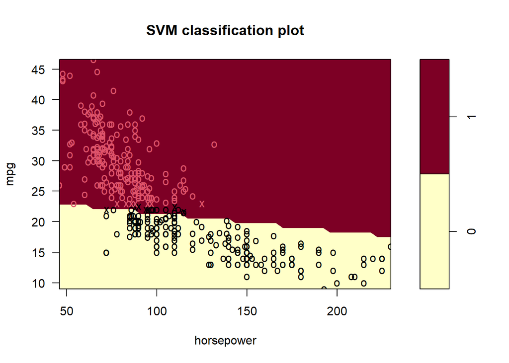

```r
svc.7 = svm(gasmil~., data=df7, kernel="linear", scale=F, cost=1)
plot( svc.7, df7, mpg~horsepower)
```

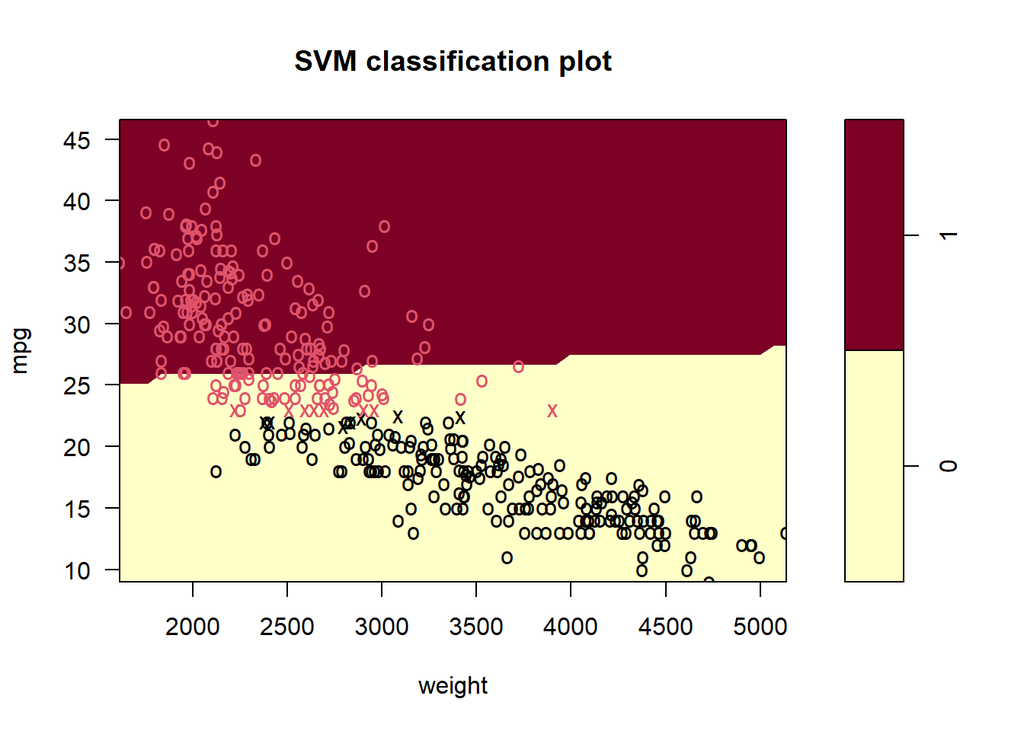

```r
plot( svc.7, df7, mpg~weight)
```